# Final Project

### Group Members

Jaime Zepeda Pina, Pranshu Dewagan, and Chris Shu

# Introduction

New York City’s rat problem has been ongoing for decades, with millions of rats [^1] estimated to live in the city. To control the rat population, the city’s health department has been monitoring rat sightings reported by residents over several years until the present day. This report investigates the relationship between rat sightings and temperature in the city int the years 2010-2020, and finds a direct correlation between the two variables. Our findings suggest that interventions targeted at reducing rat populations during warmer months may be effective in addressing the issue.

# Background - Overview of the CSVs

The first dataset, which contains information on rat sightings in New York, was obtained from the NYC Open Data Website [^2]. It provides a comprehensive record of rat sightings over a period of several years. It is probably the most reliable source of information on about rat sightings, but of course it will be missing any unreported sightings and there may be an unusual uptick in the 2020 data during the COVID-19 lockdown as people stayed in their homes, letting trash accumulate outside[^3].

```
## # A tibble: 132 × 3
##     year month count
##    <dbl> <ord> <int>
##  1  2010 Jan     528
##  2  2010 Feb     425
##  3  2010 Mar     831
##  4  2010 Apr     912
##  5  2010 May    1066
##  6  2010 Jun    1161
##  7  2010 Jul    1289
##  8  2010 Aug    1321
##  9  2010 Sep    1040
## 10  2010 Oct     875
## # … with 122 more rows
```

The second dataset, which contains temperature recordings in New York over the years, was obtained from the National Weather Service [^4]. We decided to include this dataset because we believe that temperature may be an important environmental factor that can affect rat behavior and population dynamics.

```
## # A tibble: 132 × 4
##    year  annual month   avg
##    <chr>  <dbl> <ord> <dbl>
##  1 2010    56.7 Jan    32.5
##  2 2010    56.7 Feb    33.1
##  3 2010    56.7 Mar    48.2
##  4 2010    56.7 Apr    57.9
##  5 2010    56.7 May    65.3
##  6 2010    56.7 Jun    74.7
##  7 2010    56.7 Jul    81.3
##  8 2010    56.7 Aug    77.4
##  9 2010    56.7 Sep    71.1
## 10 2010    56.7 Oct    58.1
## # … with 122 more rows
```

By analyzing these two datasets, we hope to gain insights into how temperature fluctuations and other weather-related factors may influence the frequency and distribution of rat sightings in New York. We will use statistical analysis to identify patterns and correlations in the data.

# Analysis

## Graphing the number of Rats spotted for each Month

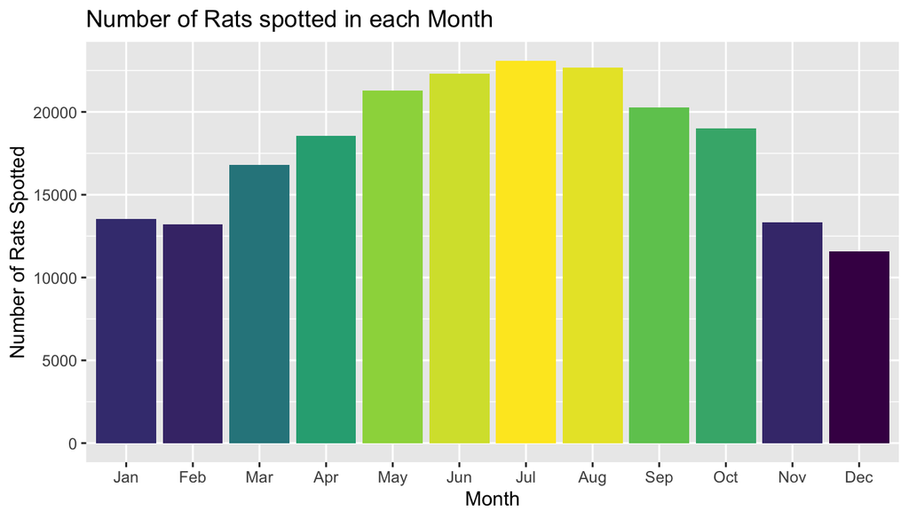

### For each year, there is a common general trend of the summer months having the highest temperatures and the winter months having the lowest

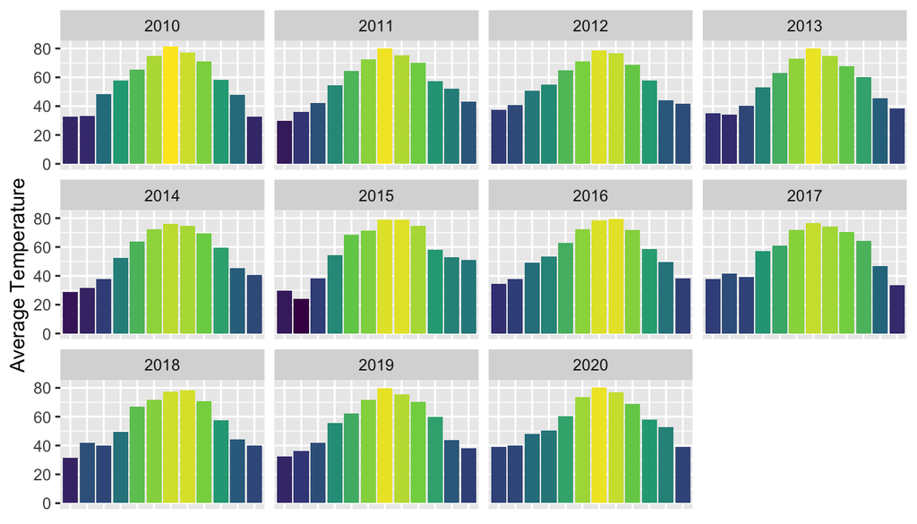

## Graphing the Average Temperature of each Month

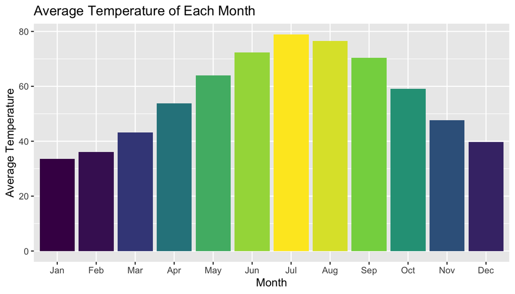

## Correlation between Temperature and Rat Sightings

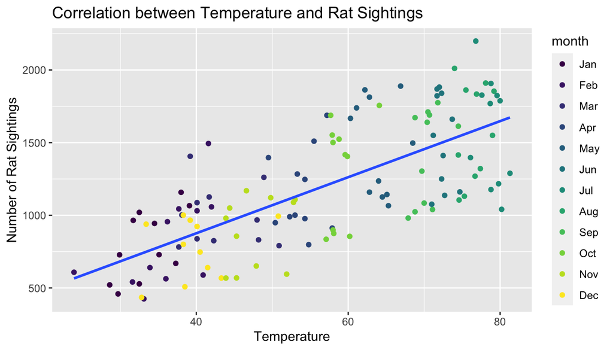

```
##
## Call:
## lm(data = merged_df)
##
## Residuals:
##     Min      1Q  Median      3Q     Max
## -566.71 -255.88   38.81  238.07  649.87
##
## Coefficients:
##             Estimate Std. Error t value Pr(>|t|)
## (Intercept)  220.672    469.335   0.470   0.6391
## x             17.228      8.329   2.068   0.0408 *
## month.L     -120.641    168.598  -0.716   0.4757
## month.Q     -169.528    409.100  -0.414   0.6793
## month.C      -18.345    134.268  -0.137   0.8916
## month^4       16.865    135.058   0.125   0.9008
## month^5      -38.152     92.966  -0.410   0.6823
## month^6       70.207     89.764   0.782   0.4357
## month^7       95.000     89.879   1.057   0.2927
## month^8       45.228     89.716   0.504   0.6151
## month^9        8.239     89.857   0.092   0.9271
## month^10     106.721     89.920   1.187   0.2377
## month^11     -13.534     90.122  -0.150   0.8809
## ---
## Signif. codes:  0 '***' 0.001 '**' 0.01 '*' 0.05 '.' 0.1 ' ' 1
##
## Residual standard error: 297.5 on 119 degrees of freedom
## Multiple R-squared:  0.552,  Adjusted R-squared:  0.5068
## F-statistic: 12.22 on 12 and 119 DF,  p-value: 7.764e-16
```

# Discussion

Based on our analysis, we found a strong correlation between temperature and rat sightings in New York City from 2010 to 2020. Specifically, warmer temperatures were associated with an increase in rat sightings. We also noted that the summer months had the highest temperatures and the highest number of rat sightings.

While our findings suggest that interventions targeted at reducing rat populations during warmer months may be effective, we acknowledge that this approach alone may not solve the problem entirely. Other factors, such as population density and access to food, may also play a role in the rat problem.

One limitation of our study is that we only considered temperature as a potential environmental factor. Future studies could explore the impact of other factors, such as humidity and precipitation, on rat behavior and population dynamics. Additionally, our study only analyzed data from 2010 to 2020, and it would be beneficial to analyze data from earlier and later years to determine if there have been any long-term trends in the relationship between temperature and rat sightings. We could also, in the future, measure differences in rat sightings by borough or neighborhood to see if there is an inverse correlation between income levels and the amount of rat sightings.

In conclusion, our analysis indicates that temperature is a significant factor in the frequency and distribution of rat sightings in New York City. However, additional research is needed to fully understand the complex dynamics of the city’s rat population and to develop effective interventions to address the issue.

[^1]: https://insider.com/new-york-city-explosive-increase-rats-over-last-65-years-2023
[^2]: https://data.cityofnewyork.us/Social-Services/Rat-Sightings/3q43-55fe
[^3]: https://www.nbcnewyork.com/news/local/more-rat-sightings-in-nyc-than-ever-before-data-shows-to-surprise-of-no-one/3907295/
[^4]: https://www.weather.gov/media/okx/Climate/CentralPark/monthlyannualtemp.pdf